# 101camp1py

ch00.蟒营

190414 2042

# 101

## Camp

> 私塾式陪伴

## intro.

> uself
- 你是谁?
- 在哪儿?
- 为什么参加蟒营?

## WoW

> 预约学员嗯哼…

## [#8](https://gitlab.com/101camp/1py/tasks/issues/8#note_158721253)

> @near8023

首杀+slack提醒缺漏发现

## SM:

> 隐藏任务 (Secret Mission)

## [#4](https://gitlab.com/101camp/1py/tasks/issues/4#note_158186932)

> @zheng2019

Slack vs 微信 ?

## [#3](https://gitlab.com/101camp/1py/tasks/issues/3#note_158175465)

> @L-luffy

`[SM]最简日常 git 操作指北`

## [#5](https://gitlab.com/101camp/1py/tasks/issues/5#note_158415372)

> @nocynic

`蟒营课程用最简 Markdown 实用指北`

## [#9](https://gitlab.com/101camp/1py/tasks/issues/9#note_159181830)

> @chengyuan101

Pyenv? 多版本环境嗯哼

## BC

> 血案(Blood Case)

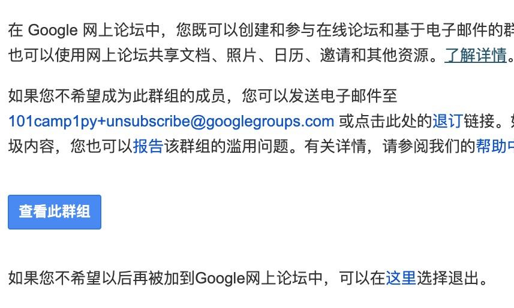

注册?

## [#29](https://gitlab.com/101camp/1py/tasks/issues/29)

> tasks.wiki 大量被删除

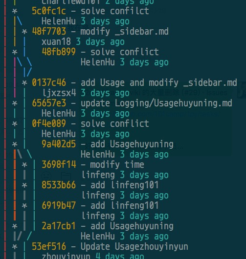

git ll -23

# rhythm

## 节奏

> ˈriT͟Həm

## 习惯

> 8周+

## daily

> 嗯哼
- 固定时间
  - 10+小时/周
- 解决问题
- 持续记录
- 认真交流

## 环境

> gitlab -> 用之, 弗学
- Issue -> 发问/起/记录/…
- Wiki -> 交付/沉淀/复用/..
- repo. -> 追踪/协同/原稿/…
- Slack -> 日常嗯哼/提醒
- ggroups -> 异步嗯哼/提醒/发布/通知
- 微信群 -> …

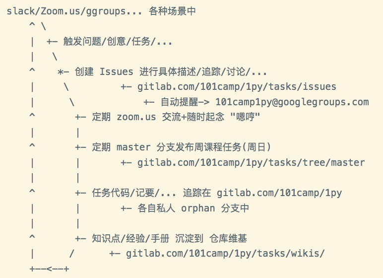

## GoogleGroups

- [电邮靠谱指南](http://blog.zhgdg.org/2014-02/email-kaopulity-guider/)
- [Gmail 生活指南](http://blog.zhgdg.org/2014-02/livin-gmail-guider/)
- [程序员必知必会之Email篇](http://blog.csdn.net/lanphaday/article/details/850059)
- [程序员必知必会之maillist篇](http://blog.csdn.net/lanphaday/article/details/1669326)

## Slack

- ? 微信
- ? QQ
- [为什么不应该使用QQ进行技术交流](http://blog.zhgdg.org/2013-06/anti-qq-as-tech-communication/)

## weekly

> 嗯哼

## 周日

> 2042 zoom.us
- WoW
- 单口/要点/…
- Q&A

## 周一

> 2042 周刊发布
- 内部刊
- 活性/工量
- 责编 -> 全体
- 撰稿 -> 日常
  - 例会 Issue 回复

[figure not shown]

任务泳道

# learnning

[figure not shown]

## 什么是”学会”?

> 学会, 什么…

## Levels

> 知识层级

## Unknow Unknow

> 不知己不知

## Unknow Know

> 不知己知何

## Know Knowed

> 知己何已知

## Know Unknow

> 知己何不知

[什么是”课”?](http://wiki.zoomquiet.io/IMHO/om-what-is-ke)

## 编程

> Pythonic

## 教练

## 醉点

## 视而不见

[figure not shown]

BC

[figure not shown]

askdama@googlegroups.com

# (￣▽￣)

## 幻灯

> NOT PPT

[slides.101.camp/101camp1pych0](http://slides.101.camp/101camp1pych0.html)

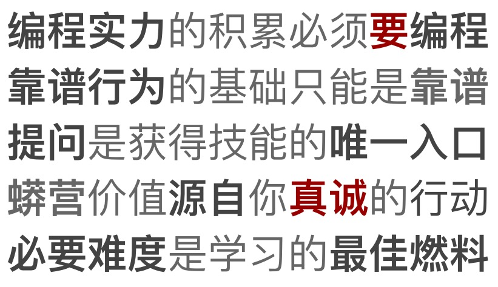

嗯哼

## 是也乎

- 190407 ++嗯哼
  - 2020 ++BC
- 190403 ++pyramid
- 190401 init.